# [EM1413] - Demographic and Lifesytle Behaviors and the Likelihood of suffering Diabetes

Alireza Zafar Vahedian (908840)

Samuel Aidoo (908825)

Sanober Sanober (908664)

# 1 Problem Definition

Diabetes prevalence is a major global health concern, affecting millions globally and putting a strain on healthcare systems. This project investigates behavioral and demographic risk factors associated with diabetes using the Behavioral Risk Factor Surveillance System (BRFSS 2022) dataset. The primary objective is to identify patterns and predictors of diabetes occurrence, thereby supporting early intervention and targeted public health strategies. The central research question is:  
**“What demographic and lifestyle-related variables significantly influence the probability of being diagnosed with diabetes?”**

# 2 Abstract

This study conducts a comprehensive statistical analysis and predictive modeling to explore the prevalence and determinants of diabetes using the **2022 Behavioral Risk Factor Surveillance System (BRFSS) dataset**. The aim is to identify key demographic, lifestyle, and health-related factors influencing diabetes and to develop robust predictive models for early detection.

The methodology comprises multiple stages, beginning with meticulous data cleaning and preparation, including filtering for valid survey weights, handling missing values, and re-coding variables into meaningful categorical factors. Descriptive analyses illustrate the overall prevalence and distribution of diabetes across subgroups, supported by detailed cross-tabulations and visualizations. Statistical associations between diabetes status and categorical variables are assessed using Chi-square tests, with effect size measures such Cramér’s V calculated to quantify association strength.

For predictive modeling, two machine learning algorithms—**Logistic Regression and Random Forest** were implemented. The data was split into training (80%) and testing (20%) sets for robust evaluation. Each model’s performance was assessed using Accuracy, Sensitivity, Specificity, and Area Under the Receiver Operating Characteristic Curve (AUC). Logistic Regression provided insights through Odds Ratios and confidence intervals, while Random Forest analysis highlighted variable importance.

# 3 Data Description

The initial raw dataset contained **344 variables and 433,325 observations**. To optimize analytical focus and computational efficiency, rigorous data cleaning and filtering were performed, including selection for valid survey weights, handling of missing data, and extraction of relevant variables. The final analytical sample consists of **14 variables** and **243,778 observations**, saved as `cleaned_responses`. Records with missing or invalid responses in key variables were excluded.

**Key variables:**

- **Outcome Variable:**
  - `DIABETE4` (recoded as Diabetes): Indicates if the respondent has ever been diagnosed with diabetes. Recoded into a binary factor: “Yes” (diagnosed diabetes) vs. “No” (excluding pre-diabetes and gestational diabetes).
- **Predictor Variables:**
  - **Gender** (`SEXVAR`): Biological sex.
  - **AgeGroup** (`X_AGE80`): Age categorized (e.g., “<30”, “30–50”, “50–70”, “70+”).
  - **Education** (`EDUCA`): Highest education level.
  - **Income** (`INCOME3`): Household income.
  - **Race** (`X_IMPRACE`): Racial/ethnic background.
  - **GeneralHealth** (`GENHLTH`): Self-rated health status.
  - **MentalHealth** (`MENTHLTH`): Self-reported mental health (good/poor).
  - **BMIRisk** (`X_RFBMI5`): BMI categories (“Overweight/Obese” vs. “Normal Weight”).
  - **HighBP** (`X_RFHYPE6`): Ever told high blood pressure.
  - **HighChol** (`X_RFCHOL3`): Ever told high cholesterol.
  - **PhysicalActivity** (`X_TOTINDA`): Physical activity engagement.
  - **Smoking** (`X_RFSMOK3`): Current smoking status.
  - **Alcohol_Consumption** (`X_RFDRHV8`): Alcohol consumption status.

BRFSS uses a complex sampling design with survey weights (`X_LLCPWT`) to ensure representativeness. These weights are crucial for valid inference and were applied in filtering to retain only valid responses.

# 4 Setup and Libraries

# 5 Uploading and Preparing the Dataset

Prior to analysis, a structured cleaning process was applied to the raw BRFSS dataset to ensure quality and consistency of the data:

```r
responses = read_csv("C:\\Users\\DELL\\Desktop\\Health Data Project Files\\responses.csv")
```

## 5.1 Filter for valid weights

```r
responses <- responses %>% filter(X_LLCPWT > 0)
```

Observations with zero or missing survey weights were removed to ensure meaningful weighted analysis.

## 5.2 Drop columns with >50% missing values

```r
responses <- responses %>% select(where(~ mean(is.na(.)) < 0.5))
```

## 5.3 Variables with more than 50% missing data were excluded to maintain data quality.

```r
responses <- responses %>%
  filter(DIABETE4 %in% c(1, 3)) %>%
  mutate(X_DIABETE4 = factor(
    ifelse(DIABETE4 == 1, 1, 0),
    levels = c(0, 1),
    labels = c("No", "Yes")
  ))

table(responses$X_DIABETE4)
```

```
##
##     No    Yes
## 358706  59786
```

Only responses with a definitive “Yes” or “No” to diabetes status were retained. The variable X_DIABETE4 was created as a factor representing diabetes status for modeling.

```r
responses <- responses %>%
  select(SEXVAR, GENHLTH, MENTHLTH, DIABETE4, EDUCA, INCOME3,
         X_IMPRACE, X_TOTINDA, X_RFHYPE6, X_RFCHOL3,
         X_AGE80, X_RFBMI5, X_RFSMOK3, X_RFDRHV8)
```

choosing a specific subset of columns from the larger responses dataset. These selected variables are deemed most relevant to the study’s objectives, focusing on key demographic, health, and lifestyle factors known to be associated with diabetes. This step streamlines the dataset, making it more efficient for subsequent analytical and modeling tasks by removing extraneous or less relevant variables.

```r
invalid_counts <- tibble::tibble(
  Variable = c("GENHLTH", "MENTHLTH", "EDUCA", "INCOME3", "X_TOTINDA",
               "X_RFHYPE6", "X_RFCHOL3", "X_RFBMI5", "X_RFSMOK3", "X_RFDRHV8"),
  Invalid_Count = c(
    sum(responses$GENHLTH %in% c(7, 8, 9), na.rm = TRUE),
    sum(is.na(responses$MENTHLTH) | responses$MENTHLTH %in% c(77, 99)),
    sum(is.na(responses$EDUCA) | responses$EDUCA == 9),
    sum(is.na(responses$INCOME3) | responses$INCOME3 %in% c(11, 77, 99)),
    sum(responses$X_TOTINDA == 9, na.rm = TRUE),
    sum(responses$X_RFHYPE6 == 9, na.rm = TRUE),
    sum(is.na(responses$X_RFCHOL3) | responses$X_RFCHOL3 == 9),
    sum(responses$X_RFBMI5 == 9, na.rm = TRUE),
    sum(responses$X_RFSMOK3 == 9, na.rm = TRUE),
    sum(responses$X_RFDRHV8 == 9, na.rm = TRUE)
  )
)

print(invalid_counts)
```

```
## # A tibble: 10 × 2
##    Variable  Invalid_Count
##    <chr>             <int>
##  1 GENHLTH            1154
##  2 MENTHLTH           7622
##  3 EDUCA              2146
##  4 INCOME3          109558
##  5 X_TOTINDA          1159
##  6 X_RFHYPE6          1646
##  7 X_RFCHOL3         53416
##  8 X_RFBMI5          38910
##  9 X_RFSMOK3         22248
## 10 X_RFDRHV8         31695
```

```r
responses <- responses %>%
  filter(
    !GENHLTH %in% c(7, 8, 9),
    !is.na(MENTHLTH) & !MENTHLTH %in% c(77, 99),
    !is.na(EDUCA) & EDUCA != 9,
    !is.na(INCOME3) & !INCOME3 %in% c(11, 77, 99),
    X_TOTINDA != 9,
    X_RFHYPE6 != 9,
    !is.na(X_RFCHOL3) & X_RFCHOL3 != 9,
    X_RFBMI5 != 9,
    X_RFSMOK3 != 9,
    X_RFDRHV8 != 9
  )
```

Identifying and quantifying “invalid” or “missing” data points in key variables. Specific codes (7, 8, 9, 77, 99) in BRFSS represent non-responses or “Don’t know” entries instead of standard NA values. After documenting their frequency, all rows containing these codes are removed from specified variables. This essential cleaning step ensures analysis uses only valid responses, improving data integrity and result validity.

```r
saveRDS(responses, "responses_cleaned.rds")
write_xlsx(responses, "cleaned_responses.xlsx")
```

## 5.4 Label Columns and Recoding

```r
responses <- read_excel("cleaned_responses.xlsx")

responses <- responses %>%
  mutate(
    Diabetes = factor(DIABETE4, levels = c(3, 1), labels = c("No", "Yes")),
    Gender = factor(SEXVAR, levels = c(1, 2), labels = c("Male", "Female")),
    GeneralHealth = factor(GENHLTH, levels = 1:5, labels = c("Excellent", "Very Good", "Good", "Fair", "Poor")),
    MentalHealth = factor(ifelse(MENTHLTH == 88, 0, 1), levels = c(0, 1), labels = c("Good", "Not Good")),
    Education = factor(EDUCA, levels = 1:6, labels = c("No School", "Elementary", "Some HS", "HS Grad", "Some College", "College Grad")),
    Income = factor(INCOME3, levels = 1:10, labels = c("<$10k", "$10k-<$15k", "$15k-<$20k", "$20k-<$25k", "$25k-<$35k", "$35k-<$50k", "$50k-<$75k", "$75k-<$100k", "$100k-<$150k", "$150k-<$200k")),
    Race = factor(X_IMPRACE, levels = 1:6, labels = c("White", "Black", "Asian", "Native American", "Hispanic", "Other")),
    PhysicalActivity = factor(X_TOTINDA, levels = c(1, 2), labels = c("Active", "Inactive")),
    HighBP = factor(X_RFHYPE6, levels = c(1, 2), labels = c("No", "Yes")),
    HighChol = factor(X_RFCHOL3, levels = c(1, 2), labels = c("No", "Yes")),
    Age = X_AGE80,
    BMIRisk = factor(X_RFBMI5, levels = c(1, 2), labels = c("Overweight/Obese", "Normal")),
    Smoking = factor(X_RFSMOK3, levels = c(1, 2), labels = c("No", "Yes")),
    Alcohol_Consumption = factor(X_RFDRHV8, levels = c(1, 2), labels = c("No", "Yes"))
  )
```

```r
# Create AgeGroup
responses <- responses %>%
  mutate(AgeGroup = case_when(
    Age < 30 ~ "<30",
    Age >= 30 & Age < 50 ~ "30-50",
    Age >= 50 & Age < 70 ~ "50-70",
    Age >= 70 ~ "70+"
  )) %>%
  mutate(AgeGroup = factor(AgeGroup, levels = c("<30", "30-50", "50-70", "70+")))
```

# 6 Descriptive Analysis

In this section, we will conduct a comprehensive descriptive analysis . The primary goal is to gain a foundational understanding of the study population’s characteristics and the distribution of our key variables, including demographic, health-related, and behavioral factors, as well as the overall prevalence of diabetes.

```r
# Overall Diabetes Status
tabyl(responses$Diabetes) %>%
  adorn_pct_formatting()
```

```
##  responses$Diabetes      n percent
##                  No 204350   83.8%
##                 Yes  39428   16.2%
```

```r
# Labeled cross-tabs
tabyl(responses, Diabetes, Gender) %>% adorn_percentages("col") %>% adorn_pct_formatting() %>% adorn_ns()
```

```
##  Diabetes           Male          Female
##        No 82.5% (96,117) 85.0% (108,233)
##       Yes 17.5% (20,319) 15.0%  (19,109)
```

```r
tabyl(responses, Diabetes, AgeGroup) %>% adorn_percentages("col") %>% adorn_pct_formatting() %>% adorn_ns()
```

```
##  Diabetes            <30          30-50          50-70            70+
##        No 98.2% (18,050) 92.7% (54,142) 80.5% (77,635) 77.3% (54,523)
##       Yes  1.8%    (335)  7.3%  (4,278) 19.5% (18,776) 22.7% (16,039)
```

```r
tabyl(responses, Diabetes, Race) %>% adorn_percentages("col") %>% adorn_pct_formatting() %>% adorn_ns()
```

```
##  Diabetes           White          Black         Asian Native American
##        No 84.8% (157,312) 76.4% (14,172) 86.2% (4,821)   75.1% (2,873)
##       Yes 15.2%  (28,261) 23.6%  (4,388) 13.8%   (771)   24.9%   (954)
##        Hispanic         Other
##  83.6% (18,203) 82.4% (6,969)
##  16.4%  (3,562) 17.6% (1,492)
```

```r
tabyl(responses, Diabetes, Education) %>% adorn_percentages("col") %>% adorn_pct_formatting() %>% adorn_ns()
```

```
##  Diabetes   No School    Elementary       Some HS        HS Grad   Some College
##        No 67.6% (121) 71.6% (2,271) 74.9% (5,700) 80.5% (46,306) 82.0% (55,955)
##       Yes 32.4%  (58) 28.4%   (903) 25.1% (1,911) 19.5% (11,184) 18.0% (12,248)
##    College Grad
##  87.7% (93,997)
##  12.3% (13,124)
```

```r
tabyl(responses, Diabetes, Income) %>% adorn_percentages("col") %>% adorn_pct_formatting() %>% adorn_ns()
```

```
##  Diabetes         <$10k    $10k-<$15k    $15k-<$20k    $20k-<$25k
##        No 76.5% (4,458) 71.2% (4,872) 74.3% (6,650) 75.5% (9,680)
##       Yes 23.5% (1,366) 28.8% (1,975) 25.7% (2,299) 24.5% (3,133)
##      $25k-<$35k     $35k-<$50k     $50k-<$75k    $75k-<$100k   $100k-<$150k
##  78.8% (21,724) 81.6% (28,678) 84.4% (37,973) 87.1% (33,929) 89.2% (37,984)
##  21.2%  (5,862) 18.4%  (6,461) 15.6%  (7,021) 12.9%  (5,007) 10.8%  (4,595)
##    $150k-<$200k
##  91.5% (18,402)
##   8.5%  (1,709)
```

```r
tabyl(responses, Diabetes, PhysicalActivity) %>% adorn_percentages("col") %>% adorn_pct_formatting() %>% adorn_ns()
```

```
##  Diabetes          Active       Inactive
##        No 87.0% (161,144) 73.7% (43,206)
##       Yes 13.0%  (24,017) 26.3% (15,411)
```

```r
tabyl(responses, Diabetes, Smoking) %>% adorn_percentages("col") %>% adorn_pct_formatting() %>% adorn_ns()
```

```
##  Diabetes              No            Yes
##        No 83.9% (181,440) 83.5% (22,910)
##       Yes 16.1%  (34,907) 16.5%  (4,521)
```

```r
tabyl(responses, Diabetes, Alcohol_Consumption) %>% adorn_percentages("col") %>% adorn_pct_formatting() %>% adorn_ns()
```

```
##  Diabetes              No            Yes
##        No 83.2% (190,593) 92.8% (13,757)
##       Yes 16.8%  (38,353)  7.2%  (1,075)
```

```r
tabyl(responses, Diabetes, BMIRisk) %>% adorn_percentages("col") %>% adorn_pct_formatting() %>% adorn_ns()
```

```
##  Diabetes Overweight/Obese          Normal
##        No   92.1% (64,078) 80.5% (140,272)
##       Yes    7.9%  (5,501) 19.5%  (33,927)
```

```r
tabyl(responses, Diabetes, GeneralHealth) %>% adorn_percentages("col") %>% adorn_pct_formatting() %>% adorn_ns()
```

```
##  Diabetes      Excellent      Very Good           Good           Fair
##        No 96.2% (31,359) 91.5% (75,284) 81.3% (66,654) 68.3% (24,097)
##       Yes  3.8%  (1,229)  8.5%  (7,021) 18.7% (15,376) 31.7% (11,170)
##           Poor
##  60.0% (6,956)
##  40.0% (4,632)
```

```r
tabyl(responses, Diabetes, HighBP) %>% adorn_percentages("col") %>% adorn_pct_formatting() %>% adorn_ns()
```

```
##  Diabetes              No            Yes
##        No 92.5% (125,784) 72.8% (78,566)
##       Yes  7.5%  (10,147) 27.2% (29,281)
```

```r
tabyl(responses, Diabetes, HighChol) %>% adorn_percentages("col") %>% adorn_pct_formatting() %>% adorn_ns()
```

```
##  Diabetes              No            Yes
##        No 90.2% (126,949) 75.1% (77,401)
##       Yes  9.8%  (13,768) 24.9% (25,660)
```

```r
# Descriptive Statistics for Age
responses %>%
  group_by(Diabetes) %>%
  summarise(
    Mean_Age = mean(Age, na.rm = TRUE),
    SD_Age = sd(Age, na.rm = TRUE),
    Min_Age = min(Age, na.rm = TRUE),
    Max_Age = max(Age, na.rm = TRUE),
    N = n()
  )
```

```
## # A tibble: 2 × 6
##   Diabetes Mean_Age SD_Age Min_Age Max_Age      N
##   <fct>       <dbl>  <dbl>   <dbl>   <dbl>  <int>
## 1 No           55.9   17.2      18      80 204350
## 2 Yes          64.7   12.0      18      80  39428
```

```r
# Recode DIABETE4 to factor (1=Yes, 3=No)

responses <- responses %>%
  filter(DIABETE4 %in% c(1, 3)) %>%  # Valid values only
  mutate(
    X_DIABETE4 = factor(
      DIABETE4,
      levels = c(3, 1),  # 3=No, 1=Yes
      labels = c("No", "Yes")
    )
  )

# Check the conversion result
table(responses$X_DIABETE4)
```

```
##
##     No    Yes
## 204350  39428
```

```r
# Converting the diabetes variable (1=Yes, 3=No)
responses <- responses %>%
  filter(DIABETE4 %in% c(1, 3)) %>%
  mutate(
    Diabetes = factor(
      DIABETE4,
      levels = c(3, 1),
      labels = c("No", "Yes")
    )
  )

# Checking the data structure
glimpse(responses)
```

```
## Rows: 243,778
## Columns: 30
## $ SEXVAR              <dbl> 2, 2, 2, 2, 1, 1, 2, 1, 2, 2, 2, 1, 2, 1, 2, 2, 1,…
## $ GENHLTH             <dbl> 4, 4, 3, 3, 3, 3, 2, 3, 3, 4, 3, 3, 3, 2, 3, 2, 2,…
## $ MENTHLTH            <dbl> 2, 88, 3, 88, 88, 88, 88, 88, 88, 88, 25, 88, 88, …
## $ DIABETE4            <dbl> 3, 1, 3, 3, 1, 3, 3, 3, 3, 3, 3, 1, 1, 3, 1, 1, 3,…
## $ EDUCA               <dbl> 4, 5, 5, 5, 4, 5, 6, 5, 5, 4, 5, 4, 4, 4, 5, 5, 5,…
## $ INCOME3             <dbl> 2, 7, 7, 6, 7, 7, 9, 9, 9, 3, 5, 6, 5, 4, 6, 6, 8,…
## $ X_IMPRACE           <dbl> 2, 1, 2, 2, 1, 1, 1, 1, 2, 2, 1, 1, 2, 1, 2, 1, 1,…
## $ X_TOTINDA           <dbl> 1, 1, 1, 2, 1, 1, 1, 2, 2, 1, 2, 1, 1, 1, 1, 2, 1,…
## $ X_RFHYPE6           <dbl> 2, 2, 2, 2, 2, 2, 1, 1, 2, 2, 2, 2, 2, 2, 2, 2, 2,…
## $ X_RFCHOL3           <dbl> 2, 1, 2, 2, 2, 2, 1, 1, 1, 1, 1, 2, 1, 2, 2, 2, 2,…
## $ X_AGE80             <dbl> 80, 76, 62, 80, 75, 59, 68, 79, 79, 80, 68, 79, 80…
## $ X_RFBMI5            <dbl> 1, 2, 2, 2, 1, 2, 2, 1, 2, 2, 2, 2, 2, 2, 2, 1, 2,…
## $ X_RFSMOK3           <dbl> 1, 1, 1, 1, 1, 1, 1, 1, 1, 1, 2, 1, 1, 1, 1, 1, 1,…
```

[output cut: 17 more lines]

## 6.1 Overall Diabetes Prevalence

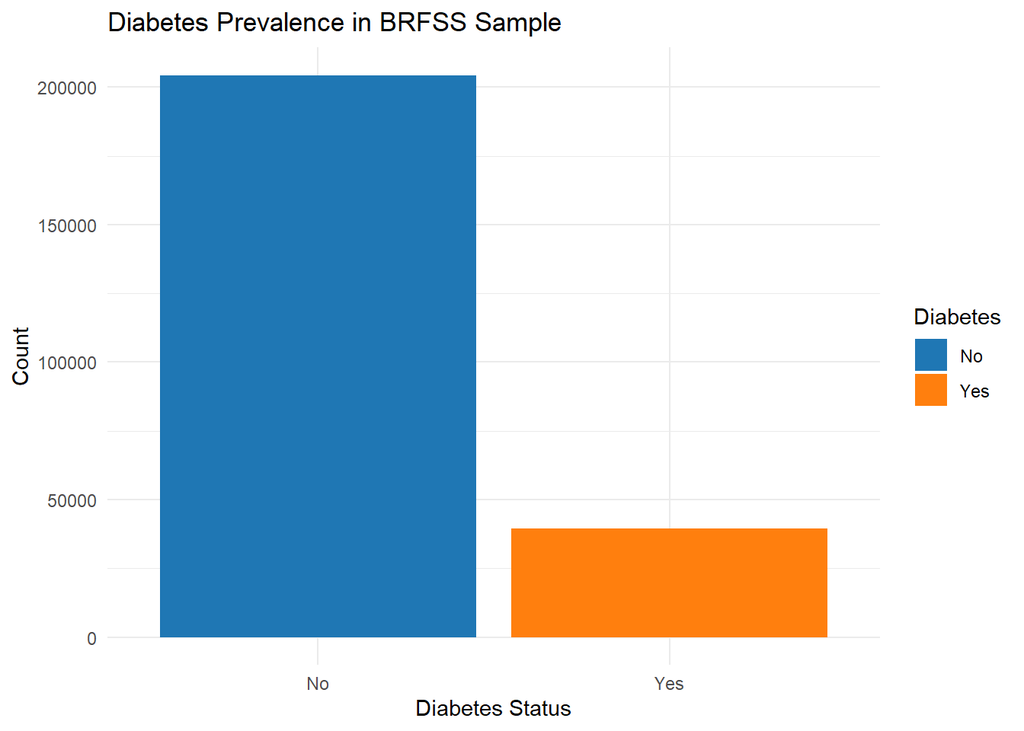

```r
ggplot(responses, aes(x = X_DIABETE4, fill = X_DIABETE4)) +
  geom_bar() +
  labs(
    title = "Diabetes Prevalence in BRFSS Sample",
    x = "Diabetes Status",
    y = "Count",
    fill = "Diabetes"
  ) +
  scale_fill_manual(values = c("No" = "#1f77b4", "Yes" = "#ff7f0e")) +
  theme_minimal()
```

## 6.2 Diabetes by Demographic Variables

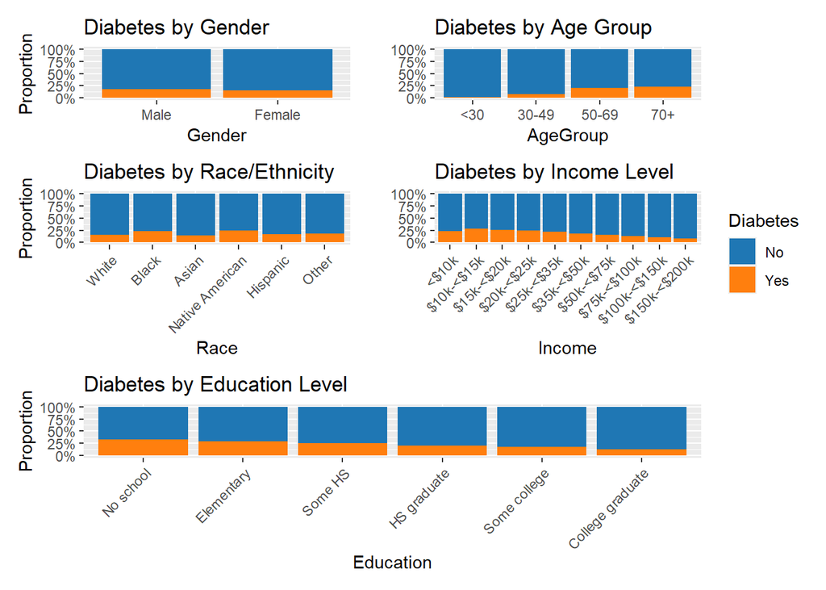

```r
# Converting demographic variables
responses <- responses %>%
  mutate(
    # Gender
    Gender = factor(SEXVAR,
                   levels = c(1, 2),
                   labels = c("Male", "Female")),

    # Age group
    AgeGroup = cut(X_AGE80,
                  breaks = c(0, 30, 50, 70, Inf),
                  labels = c("<30", "30-49", "50-69", "70+")),

    # Race/Ethnicity
    Race = factor(X_IMPRACE,
                 levels = 1:6,
                 labels = c("White", "Black", "Asian",
                           "Native American", "Hispanic", "Other")),

    # Income
    Income = factor(INCOME3,
                   levels = 1:10,
                   labels = c("<$10k", "$10k-<$15k", "$15k-<$20k",
                             "$20k-<$25k", "$25k-<$35k", "$35k-<$50k",
                             "$50k-<$75k", "$75k-<$100k", "$100k-<$150k",
                             "$150k-<$200k")),

    # Education
    Education = factor(EDUCA,
                      levels = 1:6,
                      labels = c("No school", "Elementary", "Some HS",
                               "HS graduate", "Some college", "College graduate"))
  )

# Demographic plots
p_gender <- ggplot(responses, aes(x = Gender, fill = Diabetes)) +
  geom_bar(position = "fill") +
  scale_y_continuous(labels = percent_format()) +
  labs(title = "Diabetes by Gender", y = "Proportion")

p_age <- ggplot(responses, aes(x = AgeGroup, fill = Diabetes)) +
  geom_bar(position = "fill") +
  scale_y_continuous(labels = percent_format()) +
  labs(title = "Diabetes by Age Group", y = "")

p_race <- ggplot(responses, aes(x = Race, fill = Diabetes)) +
  geom_bar(position = "fill") +
  scale_y_continuous(labels = percent_format()) +
  labs(title = "Diabetes by Race/Ethnicity", y = "Proportion") +
  theme(axis.text.x = element_text(angle = 45, hjust = 1))

p_income <- ggplot(responses, aes(x = Income, fill = Diabetes)) +
  geom_bar(position = "fill") +
  scale_y_continuous(labels = percent_format()) +
  labs(title = "Diabetes by Income Level", y = "") +
  theme(axis.text.x = element_text(angle = 45, hjust = 1))

p_edu <- ggplot(responses, aes(x = Education, fill = Diabetes)) +
  geom_bar(position = "fill") +
  scale_y_continuous(labels = percent_format()) +
  labs(title = "Diabetes by Education Level", y = "Proportion") +
  theme(axis.text.x = element_text(angle = 45, hjust = 1))

# Combined plot display
(p_gender + p_age) / (p_race + p_income) / p_edu +
  plot_layout(guides = "collect") &
  scale_fill_manual(values = c("No" = "#1f77b4", "Yes" = "#ff7f0e"))
```

## 6.3 Diabetes by Lifestyle Variables

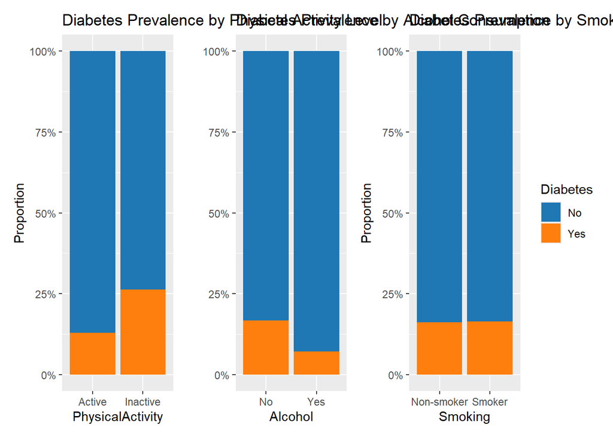

```r
# Converting lifestyle variables
responses <- responses %>%
  mutate(
    # Physical activity
    PhysicalActivity = factor(X_TOTINDA,
                            levels = c(1, 2),
                            labels = c("Active", "Inactive")),

    # Alcohol consumption
    Alcohol = factor(X_RFDRHV8,
                    levels = c(1, 2),
                    labels = c("No", "Yes")),

    # Smoking status
    Smoking = factor(X_RFSMOK3,
                    levels = c(1, 2),
                    labels = c("Non-smoker", "Smoker"))
  )

# Lifestyle plots
p_pa <- ggplot(responses, aes(x = PhysicalActivity, fill = Diabetes)) +
  geom_bar(position = "fill") +
  scale_y_continuous(labels = percent_format()) +
  labs(title = "Diabetes Prevalence by Physical Activity Level",
       y = "Proportion")

p_alc <- ggplot(responses, aes(x = Alcohol, fill = Diabetes)) +
  geom_bar(position = "fill") +
  scale_y_continuous(labels = percent_format()) +
  labs(title = "Diabetes Prevalence by Alcohol Consumption",
       y = "")

p_smoke <- ggplot(responses, aes(x = Smoking, fill = Diabetes)) +
  geom_bar(position = "fill") +
  scale_y_continuous(labels = percent_format()) +
  labs(title = "Diabetes Prevalence by Smoking Status",
       y = "Proportion")

# Combined plot display
(p_pa + p_alc + p_smoke) +
  plot_layout(guides = "collect") &
  scale_fill_manual(values = c("No" = "#1f77b4", "Yes" = "#ff7f0e"))
```

## 6.4 Diabetes by Physical health variables

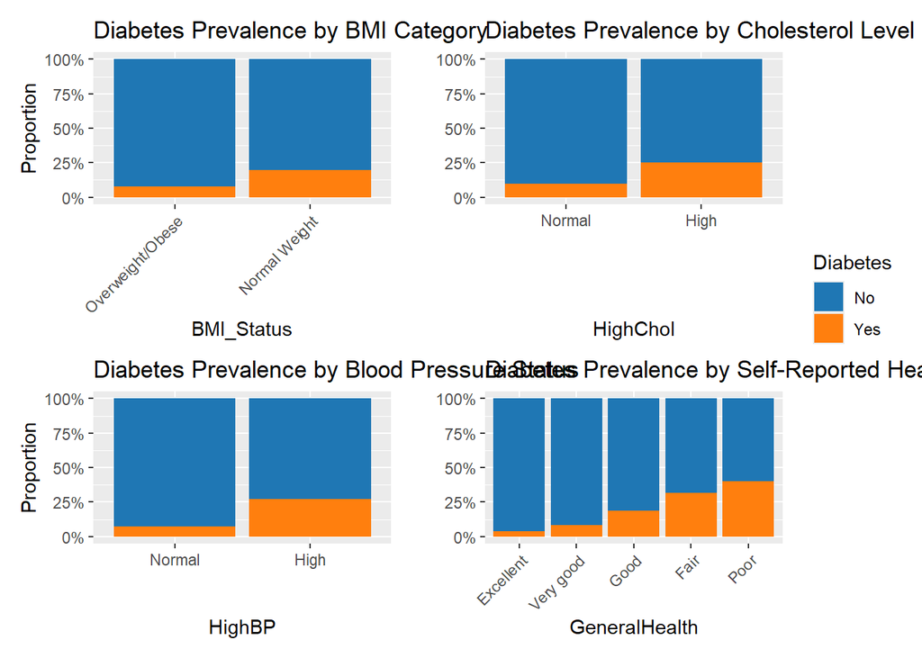

```r
# Converting physical health variables
responses <- responses %>%
  mutate(
    # BMI status
    BMI_Status = factor(X_RFBMI5,
                       levels = c(1, 2),
                       labels = c("Overweight/Obese", "Normal Weight")),

    # High cholesterol
    HighChol = factor(X_RFCHOL3,
                     levels = c(1, 2),
                     labels = c("Normal", "High")),

    # High blood pressure
    HighBP = factor(X_RFHYPE6,
                   levels = c(1, 2),
                   labels = c("Normal", "High")),

    # Self-reported health status
    GeneralHealth = factor(GENHLTH,
                          levels = 1:5,
                          labels = c("Excellent", "Very good", "Good",
                                   "Fair", "Poor"))
  )

# Physical health plots
p_bmi <- ggplot(responses, aes(x = BMI_Status, fill = Diabetes)) +
  geom_bar(position = "fill") +
  scale_y_continuous(labels = percent_format()) +
  labs(title = "Diabetes Prevalence by BMI Category",
       y = "Proportion") +
  theme(axis.text.x = element_text(angle = 45, hjust = 1))

p_chol <- ggplot(responses, aes(x = HighChol, fill = Diabetes)) +
  geom_bar(position = "fill") +
  scale_y_continuous(labels = percent_format()) +
  labs(title = "Diabetes Prevalence by Cholesterol Level",
       y = "")

p_bp <- ggplot(responses, aes(x = HighBP, fill = Diabetes)) +
  geom_bar(position = "fill") +
  scale_y_continuous(labels = percent_format()) +
  labs(title = "Diabetes Prevalence by Blood Pressure Status",
       y = "Proportion")

p_health <- ggplot(responses, aes(x = GeneralHealth, fill = Diabetes)) +
  geom_bar(position = "fill") +
  scale_y_continuous(labels = percent_format()) +
  labs(title = "Diabetes Prevalence by Self-Reported Health",
       y = "") +
  theme(axis.text.x = element_text(angle = 45, hjust = 1))

# Combined plot display
(p_bmi + p_chol + p_bp + p_health) +
  plot_layout(guides = "collect") &
  scale_fill_manual(values = c("No" = "#1f77b4", "Yes" = "#ff7f0e"))
```

## 6.5 Mental health

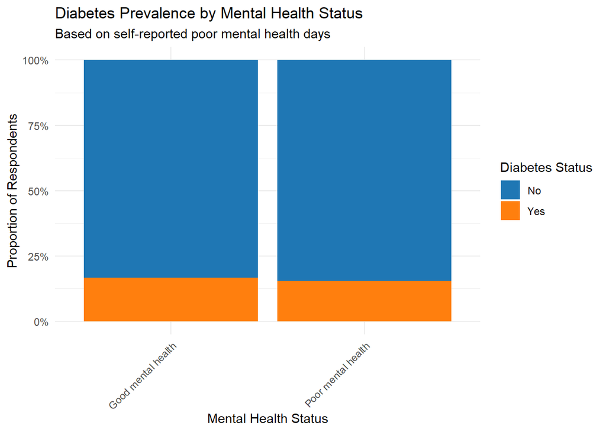

```r
# Converting mental health variable
responses <- responses %>%
  mutate(
    # Recode mental health (88 = 0 days → "Good")
    MentalHealth = ifelse(MENTHLTH == 88, 0, 1),
    MentalHealth = factor(MentalHealth,
                         levels = c(0, 1),
                         labels = c("Good mental health",
                                   "Poor mental health"))
  )

# Mental health plot
ggplot(responses, aes(x = MentalHealth, fill = Diabetes)) +
  geom_bar(position = "fill") +
  scale_y_continuous(labels = scales::percent_format()) +
  scale_fill_manual(values = c("No" = "#1f77b4", "Yes" = "#ff7f0e"),
                    name = "Diabetes Status") +
  labs(title = "Diabetes Prevalence by Mental Health Status",
       subtitle = "Based on self-reported poor mental health days",
       x = "Mental Health Status",
       y = "Proportion of Respondents") +
  theme_minimal() +
  theme(axis.text.x = element_text(angle = 45, hjust = 1))
```

## 6.6 Statistical analysis and summarization

```r
# Function to calculate diabetes prevalence
calculate_prevalence <- function(data, group_var) {
  data %>%
    group_by(!!sym(group_var)) %>%
    summarise(
      Total = n(),
      DiabetesCases = sum(Diabetes == "Yes"),
      Prevalence = DiabetesCases / Total * 100,
      .groups = "drop"
    ) %>%
    arrange(desc(Prevalence))
}

# Calculate prevalence across different groups
demographic_summary <- bind_rows(
  calculate_prevalence(responses, "Gender"),
  calculate_prevalence(responses, "AgeGroup"),
  calculate_prevalence(responses, "Race"),
  calculate_prevalence(responses, "Income"),
  calculate_prevalence(responses, "Education")
)

lifestyle_summary <- bind_rows(
  calculate_prevalence(responses, "PhysicalActivity"),
  calculate_prevalence(responses, "Alcohol"),
  calculate_prevalence(responses, "Smoking")
)

health_summary <- bind_rows(
  calculate_prevalence(responses, "BMI_Status"),
  calculate_prevalence(responses, "HighChol"),
  calculate_prevalence(responses, "HighBP"),
  calculate_prevalence(responses, "GeneralHealth"),
  calculate_prevalence(responses, "MentalHealth")
)

# Display tables
demographic_summary
```

```
## # A tibble: 28 × 8
##    Gender  Total DiabetesCases Prevalence AgeGroup Race         Income Education
##    <fct>   <int>         <int>      <dbl> <fct>    <fct>        <fct>  <fct>
##  1 Male   116436         20319      17.5  <NA>     <NA>         <NA>   <NA>
##  2 Female 127342         19109      15.0  <NA>     <NA>         <NA>   <NA>
##  3 <NA>    64207         14589      22.7  70+      <NA>         <NA>   <NA>
##  4 <NA>    99055         19691      19.9  50-69    <NA>         <NA>   <NA>
##  5 <NA>    59629          4753       7.97 30-49    <NA>         <NA>   <NA>
##  6 <NA>    20887           395       1.89 <30      <NA>         <NA>   <NA>
##  7 <NA>     3827           954      24.9  <NA>     Native Amer… <NA>   <NA>
##  8 <NA>    18560          4388      23.6  <NA>     Black        <NA>   <NA>
##  9 <NA>     8461          1492      17.6  <NA>     Other        <NA>   <NA>
## 10 <NA>    21765          3562      16.4  <NA>     Hispanic     <NA>   <NA>
## # ℹ 18 more rows
```

```r
lifestyle_summary
```

```
## # A tibble: 6 × 6
##   PhysicalActivity  Total DiabetesCases Prevalence Alcohol Smoking
##   <fct>             <int>         <int>      <dbl> <fct>   <fct>
## 1 Inactive          58617         15411      26.3  <NA>    <NA>
## 2 Active           185161         24017      13.0  <NA>    <NA>
## 3 <NA>             228946         38353      16.8  No      <NA>
## 4 <NA>              14832          1075       7.25 Yes     <NA>
## 5 <NA>              27431          4521      16.5  <NA>    Smoker
## 6 <NA>             216347         34907      16.1  <NA>    Non-smoker
```

```r
health_summary
```

```
## # A tibble: 13 × 8
##    BMI_Status       Total DiabetesCases Prevalence HighChol HighBP GeneralHealth
##    <fct>            <int>         <int>      <dbl> <fct>    <fct>  <fct>
##  1 Normal Weight   174199         33927      19.5  <NA>     <NA>   <NA>
##  2 Overweight/Obe…  69579          5501       7.91 <NA>     <NA>   <NA>
##  3 <NA>            103061         25660      24.9  High     <NA>   <NA>
##  4 <NA>            140717         13768       9.78 Normal   <NA>   <NA>
##  5 <NA>            107847         29281      27.2  <NA>     High   <NA>
##  6 <NA>            135931         10147       7.46 <NA>     Normal <NA>
##  7 <NA>             11588          4632      40.0  <NA>     <NA>   Poor
##  8 <NA>             35267         11170      31.7  <NA>     <NA>   Fair
##  9 <NA>             82030         15376      18.7  <NA>     <NA>   Good
## 10 <NA>             82305          7021       8.53 <NA>     <NA>   Very good
## 11 <NA>             32588          1229       3.77 <NA>     <NA>   Excellent
## 12 <NA>            146184         24289      16.6  <NA>     <NA>   <NA>
## 13 <NA>             97594         15139      15.5  <NA>     <NA>   <NA>
## # ℹ 1 more variable: MentalHealth <fct>
```

# 7 Chi-square Test Functions

```r
# Function to perform chi-square test
perform_chi_test <- function(data, var1, var2) {
  # Create contingency table
  tbl <- table(data[[var1]], data[[var2]])

  # Perform chi-square test with continuity correction
  chi_test <- chisq.test(tbl, correct = TRUE)

  # Return results
  list(
    contingency_table = tbl,
    chi_square = chi_test$statistic,
    df = chi_test$parameter,
    p_value = chi_test$p.value,
    expected_counts = chi_test$expected
  )
}

# Function to display results
display_chi_results <- function(chi_results, var1, var2) {
  # Create a data frame for nice display
  results_df <- data.frame(
    Test = paste(var1, "vs", var2),
    Chi_Square = round(chi_results$chi_square, 3),
    DF = chi_results$df,
    P_Value = ifelse(chi_results$p_value < 0.001,
                    "< 0.001",
                    round(chi_results$p_value, 3)),
    Status  = ifelse(chi_results$p_value < 0.05,
                         "Significant",
                         "Not Significant")
  )

  # Print contingency table
  cat("\nContingency Table:\n")
  print(chi_results$contingency_table)

  # Print formatted results
  kable(results_df) %>%
    kable_styling(bootstrap_options = c("striped", "hover"))
}
```

## 7.1 Perform Chi-square Tests

In this section, we will utilize Chi-square tests to statistically evaluate the association between our categorical predictor variables and the binary outcome variable, Diabetes (Yes/No). The Chi-square test is a fundamental non-parametric statistical test used to determine if there is a significant relationship or dependence between two nominal (categorical) variables. We will test:

Null hypothesis H0: The two categorical variables are independent (no association)

Hypothesis H1: The variables are not independent (an association exists).

```r
# Diabetes vs General Health
chi_diabetes_health <- perform_chi_test(responses, "Diabetes", "GeneralHealth")
display_chi_results(chi_diabetes_health, "Diabetes", "GeneralHealth")
```

```
##
## Contingency Table:
##
##       Excellent Very good  Good  Fair  Poor
##   No      31359     75284 66654 24097  6956
##   Yes      1229      7021 15376 11170  4632
```

|  | Test | Chi_Square | DF | P_Value | Status |
| --- | --- | --- | --- | --- | --- |
| X-squared | Diabetes vs GeneralHealth | 18732.97 | 4 | < 0.001 | Significant |

```r
# Diabetes vs BMI Risk
chi_diabetes_bmi <- perform_chi_test(responses, "Diabetes", "BMIRisk")
display_chi_results(chi_diabetes_bmi, "Diabetes", "BMIRisk")
```

```
##
## Contingency Table:
##
##       Overweight/Obese Normal
##   No             64078 140272
##   Yes             5501  33927
```

|  | Test | Chi_Square | DF | P_Value | Status |
| --- | --- | --- | --- | --- | --- |
| X-squared | Diabetes vs BMIRisk | 4908.188 | 1 | < 0.001 | Significant |

```r
# Diabetes vs High Blood Pressure
chi_diabetes_bp <- perform_chi_test(responses, "Diabetes", "HighBP")
display_chi_results(chi_diabetes_bp, "Diabetes", "HighBP")
```

```
##
## Contingency Table:
##
##       Normal   High
##   No  125784  78566
##   Yes  10147  29281
```

|  | Test | Chi_Square | DF | P_Value | Status |
| --- | --- | --- | --- | --- | --- |
| X-squared | Diabetes vs HighBP | 17187.24 | 1 | < 0.001 | Significant |

```r
# Diabetes vs Education
chi_diabetes_edu <- perform_chi_test(responses, "Diabetes", "Education")
display_chi_results(chi_diabetes_edu, "Diabetes", "Education")
```

```
##
## Contingency Table:
##
##       No school Elementary Some HS HS graduate Some college College graduate
##   No        121       2271    5700       46306        55955            93997
##   Yes        58        903    1911       11184        12248            13124
```

|  | Test | Chi_Square | DF | P_Value | Status |
| --- | --- | --- | --- | --- | --- |
| X-squared | Diabetes vs Education | 2667.562 | 5 | < 0.001 | Significant |

```r
# Diabetes vs Physical Activity
chi_diabetes_pa <- perform_chi_test(responses, "Diabetes", "PhysicalActivity")
display_chi_results(chi_diabetes_pa, "Diabetes", "PhysicalActivity")
```

```
##
## Contingency Table:
##
##       Active Inactive
##   No  161144    43206
##   Yes  24017    15411
```

|  | Test | Chi_Square | DF | P_Value | Status |
| --- | --- | --- | --- | --- | --- |
| X-squared | Diabetes vs PhysicalActivity | 5825.486 | 1 | < 0.001 | Significant |

```r
chi_diabetes_gender <- perform_chi_test(responses, "Diabetes", "Gender")
display_chi_results(chi_diabetes_gender, "Diabetes", "Gender")
```

```
##
## Contingency Table:
##
##         Male Female
##   No   96117 108233
##   Yes  20319  19109
```

|  | Test | Chi_Square | DF | P_Value | Status |
| --- | --- | --- | --- | --- | --- |
| X-squared | Diabetes vs Gender | 267.946 | 1 | < 0.001 | Significant |

```r
chi_diabetes_income <- perform_chi_test(responses, "Diabetes", "Income")
display_chi_results(chi_diabetes_income, "Diabetes", "Income")
```

```
##
## Contingency Table:
##
##       <$10k $10k-<$15k $15k-<$20k $20k-<$25k $25k-<$35k $35k-<$50k $50k-<$75k
##   No   4458       4872       6650       9680      21724      28678      37973
##   Yes  1366       1975       2299       3133       5862       6461       7021
##
##       $75k-<$100k $100k-<$150k $150k-<$200k
##   No        33929        37984        18402
##   Yes        5007         4595         1709
```

|  | Test | Chi_Square | DF | P_Value | Status |
| --- | --- | --- | --- | --- | --- |
| X-squared | Diabetes vs Income | 5045.035 | 9 | < 0.001 | Significant |

```r
chi_diabetes_race <- perform_chi_test(responses, "Diabetes", "Race")
display_chi_results(chi_diabetes_race, "Diabetes", "Race")
```

```
##
## Contingency Table:
##
##        White  Black  Asian Native American Hispanic  Other
##   No  157312  14172   4821            2873    18203   6969
##   Yes  28261   4388    771             954     3562   1492
```

|  | Test | Chi_Square | DF | P_Value | Status |
| --- | --- | --- | --- | --- | --- |
| X-squared | Diabetes vs Race | 1139.447 | 5 | < 0.001 | Significant |

```r
chi_diabetes_chol <- perform_chi_test(responses, "Diabetes", "HighChol")
display_chi_results(chi_diabetes_chol, "Diabetes", "HighChol")
```

```
##
## Contingency Table:
##
##       Normal   High
##   No  126949  77401
##   Yes  13768  25660
```

|  | Test | Chi_Square | DF | P_Value | Status |
| --- | --- | --- | --- | --- | --- |
| X-squared | Diabetes vs HighChol | 10021.88 | 1 | < 0.001 | Significant |

```r
chi_diabetes_smoking <- perform_chi_test(responses, "Diabetes", "Smoking")
display_chi_results(chi_diabetes_smoking, "Diabetes", "Smoking")
```

```
##
## Contingency Table:
##
##       Non-smoker Smoker
##   No      181440  22910
##   Yes      34907   4521
```

|  | Test | Chi_Square | DF | P_Value | Status |
| --- | --- | --- | --- | --- | --- |
| X-squared | Diabetes vs Smoking | 2.132 | 1 | 0.144 | Not Significant |

```r
chi_diabetes_alcohol <- perform_chi_test(responses, "Diabetes", "Alcohol_Consumption")
display_chi_results(chi_diabetes_alcohol, "Diabetes", "Alcohol_Consumption")
```

```
##
## Contingency Table:
##
##           No    Yes
##   No  190593  13757
##   Yes  38353   1075
```

|  | Test | Chi_Square | DF | P_Value | Status |
| --- | --- | --- | --- | --- | --- |
| X-squared | Diabetes vs Alcohol_Consumption | 927.354 | 1 | < 0.001 | Significant |

```r
chi_diabetes_mental <- perform_chi_test(responses, "Diabetes", "MentalHealth")
display_chi_results(chi_diabetes_mental, "Diabetes", "MentalHealth")
```

```
##
## Contingency Table:
##
##       Good mental health Poor mental health
##   No              121895              82455
##   Yes              24289              15139
```

|  | Test | Chi_Square | DF | P_Value | Status |
| --- | --- | --- | --- | --- | --- |
| X-squared | Diabetes vs MentalHealth | 52.447 | 1 | < 0.001 | Significant |

## 7.2 Check Assumptions

```r
check_assumptions <- function(chi_results, var1, var2) {
  expected <- chi_results$expected_counts
  low_cells <- sum(expected < 5)
  total_cells <- length(expected)

  assumption_df <- data.frame(
    Variable = paste(var1, "vs", var2),
    Min_Expected = min(expected),
    Cells_Below_5 = low_cells,
    Percent_Below_5 = round(low_cells/total_cells * 100, 1),
    Assumption_Met = ifelse(low_cells > 0 & any(expected < 1),
                          "Violated",
                          ifelse(low_cells > 0,
                                "Warning",
                                "OK"))
  )

  kable(assumption_df) %>%
    kable_styling(bootstrap_options = c("striped", "hover"))
}


cat("\nAssumption Checks:\n")
```

```
##
## Assumption Checks:
```

```r
check_assumptions(chi_diabetes_health, "Diabetes", "GeneralHealth")
```

| Variable | Min_Expected | Cells_Below_5 | Percent_Below_5 | Assumption_Met |
| --- | --- | --- | --- | --- |
| Diabetes vs GeneralHealth | 1874.212 | 0 | 0 | OK |

```r
check_assumptions(chi_diabetes_bmi, "Diabetes", "BMIRisk")
```

| Variable | Min_Expected | Cells_Below_5 | Percent_Below_5 | Assumption_Met |
| --- | --- | --- | --- | --- |
| Diabetes vs BMIRisk | 11253.52 | 0 | 0 | OK |

```r
check_assumptions(chi_diabetes_bp, "Diabetes", "HighBP")
```

| Variable | Min_Expected | Cells_Below_5 | Percent_Below_5 | Assumption_Met |
| --- | --- | --- | --- | --- |
| Diabetes vs HighBP | 17442.88 | 0 | 0 | OK |

```r
check_assumptions(chi_diabetes_edu, "Diabetes", "Education")
```

| Variable | Min_Expected | Cells_Below_5 | Percent_Below_5 | Assumption_Met |
| --- | --- | --- | --- | --- |
| Diabetes vs Education | 28.95098 | 0 | 0 | OK |

```r
check_assumptions(chi_diabetes_pa, "Diabetes", "PhysicalActivity")
```

| Variable | Min_Expected | Cells_Below_5 | Percent_Below_5 | Assumption_Met |
| --- | --- | --- | --- | --- |
| Diabetes vs PhysicalActivity | 9480.556 | 0 | 0 | OK |

```r
check_assumptions(chi_diabetes_gender, "Diabetes", "Gender")
```

| Variable | Min_Expected | Cells_Below_5 | Percent_Below_5 | Assumption_Met |
| --- | --- | --- | --- | --- |
| Diabetes vs Gender | 18832.05 | 0 | 0 | OK |

```r
check_assumptions(chi_diabetes_income, "Diabetes", "Income")
```

| Variable | Min_Expected | Cells_Below_5 | Percent_Below_5 | Assumption_Met |
| --- | --- | --- | --- | --- |
| Diabetes vs Income | 941.9581 | 0 | 0 | OK |

```r
check_assumptions(chi_diabetes_race, "Diabetes", "Race")
```

| Variable | Min_Expected | Cells_Below_5 | Percent_Below_5 | Assumption_Met |
| --- | --- | --- | --- | --- |
| Diabetes vs Race | 618.9687 | 0 | 0 | OK |

```r
check_assumptions(chi_diabetes_chol, "Diabetes", "Cholesterol")
```

| Variable | Min_Expected | Cells_Below_5 | Percent_Below_5 | Assumption_Met |
| --- | --- | --- | --- | --- |
| Diabetes vs Cholesterol | 16668.81 | 0 | 0 | OK |

```r
check_assumptions(chi_diabetes_smoking, "Diabetes", "Smoking")
```

| Variable | Min_Expected | Cells_Below_5 | Percent_Below_5 | Assumption_Met |
| --- | --- | --- | --- | --- |
| Diabetes vs Smoking | 4436.616 | 0 | 0 | OK |

```r
check_assumptions(chi_diabetes_alcohol, "Diabetes", "Alcohol")
```

| Variable | Min_Expected | Cells_Below_5 | Percent_Below_5 | Assumption_Met |
| --- | --- | --- | --- | --- |
| Diabetes vs Alcohol | 2398.888 | 0 | 0 | OK |

```r
check_assumptions(chi_diabetes_mental, "Diabetes", "MentalHealth")
```

| Variable | Min_Expected | Cells_Below_5 | Percent_Below_5 | Assumption_Met |
| --- | --- | --- | --- | --- |
| Diabetes vs MentalHealth | 15784.59 | 0 | 0 | OK |

## 7.3 Effect Size Measures

```r
# Function to calculate effect sizes
calculate_effect_sizes <- function(tbl) {
  n <- sum(tbl)
  cramers_v <- sqrt(chisq.test(tbl)$statistic / (n * (min(dim(tbl)) - 1)))

  data.frame(
    Cramers_V = round(cramers_v, 3),
    Interpretation = ifelse(cramers_v < 0.1, "Negligible",
                          ifelse(cramers_v < 0.3, "Small",
                                ifelse(cramers_v < 0.5, "Medium", "Large")))
  )
}

# Calculate effect sizes for each test
effect_sizes <- list(
  Health = calculate_effect_sizes(chi_diabetes_health$contingency_table),
  BMI = calculate_effect_sizes(chi_diabetes_bmi$contingency_table),
  BP = calculate_effect_sizes(chi_diabetes_bp$contingency_table),
  Education = calculate_effect_sizes(chi_diabetes_edu$contingency_table),
  PhysicalActivity = calculate_effect_sizes(chi_diabetes_pa$contingency_table),
  Gender = calculate_effect_sizes(chi_diabetes_gender$contingency_table),
  Income = calculate_effect_sizes(chi_diabetes_income$contingency_table),
  Race = calculate_effect_sizes(chi_diabetes_race$contingency_table),
  Cholesterol = calculate_effect_sizes(chi_diabetes_chol$contingency_table),
  Smoking = calculate_effect_sizes(chi_diabetes_smoking$contingency_table),
  Alcohol = calculate_effect_sizes(chi_diabetes_alcohol$contingency_table),
  MentalHealth = calculate_effect_sizes(chi_diabetes_mental$contingency_table)
)

bind_rows(effect_sizes, .id = "Comparison") %>%
  kable() %>%
  kable_styling()
```

|  | Comparison | Cramers_V | Interpretation |
| --- | --- | --- | --- |
| X-squared…1 | Health | 0.277 | Small |
| X-squared…2 | BMI | 0.142 | Small |
| X-squared…3 | BP | 0.266 | Small |
| X-squared…4 | Education | 0.105 | Small |
| X-squared…5 | PhysicalActivity | 0.155 | Small |
| X-squared…6 | Gender | 0.033 | Negligible |
| X-squared…7 | Income | 0.144 | Small |
| X-squared…8 | Race | 0.068 | Negligible |
| X-squared…9 | Cholesterol | 0.203 | Small |
| X-squared…10 | Smoking | 0.003 | Negligible |
| X-squared…11 | Alcohol | 0.062 | Negligible |
| X-squared…12 | MentalHealth | 0.015 | Negligible |

```r
model_data <- responses %>%
  select(Diabetes, Gender, Age = X_AGE80, Race, Income, Education,
         GeneralHealth, MentalHealth, BMIRisk, HighBP, HighChol,
         PhysicalActivity, Smoking, Alcohol_Consumption) %>%
  drop_na()

summary(model_data)
```

```
##  Diabetes        Gender            Age                     Race
##  No :204350   Male  :116436   Min.   :18.00   White          :185573
##  Yes: 39428   Female:127342   1st Qu.:44.00   Black          : 18560
##                               Median :60.00   Asian          :  5592
##                               Mean   :57.29   Native American:  3827
##                               3rd Qu.:71.00   Hispanic       : 21765
##                               Max.   :80.00   Other          :  8461
##
##           Income                 Education        GeneralHealth
##  $50k-<$75k  :44994   No school       :   179   Excellent:32588
##  $100k-<$150k:42579   Elementary      :  3174   Very good:82305
##  $75k-<$100k :38936   Some HS         :  7611   Good     :82030
##  $35k-<$50k  :35139   HS graduate     : 57490   Fair     :35267
##  $25k-<$35k  :27586   Some college    : 68203   Poor     :11588
##  $150k-<$200k:20111   College graduate:107121
##  (Other)     :34433
##              MentalHealth                BMIRisk          HighBP
##  Good mental health:146184   Overweight/Obese: 69579   Normal:135931
##  Poor mental health: 97594   Normal          :174199   High  :107847
##
##
##
##
##
##    HighChol      PhysicalActivity        Smoking       Alcohol_Consumption
##  Normal:140717   Active  :185161   Non-smoker:216347   No :228946
##  High  :103061   Inactive: 58617   Smoker    : 27431   Yes: 14832
##
##
##
##
##
```

```r
# Checking class equality
table(model_data$Diabetes)
```

```
##
##     No    Yes
## 204350  39428
```

```r
set.seed(123)
train_index <- createDataPartition(model_data$Diabetes, p = 0.8, list = FALSE)
train_data <- model_data[train_index, ]
test_data  <- model_data[-train_index, ]

#Ensuring both "No" and "Yes" classes are present in both datasets
train_data$Diabetes <- factor(train_data$Diabetes, levels = c("No", "Yes"))
test_data$Diabetes  <- factor(test_data$Diabetes, levels = c("No", "Yes"))

# Display class distribution in training set
table(train_data$Diabetes)
```

```
##
##     No    Yes
## 163480  31543
```

```r
table(test_data$Diabetes)
```

```
##
##    No   Yes
## 40870  7885
```

# 8 Model Building

## 8.1 Null Model

```r
# Null Model
null_model <- glm(Diabetes ~ 1, data = train_data, family = binomial)

# Prediction on test data
null_pred_prob <- predict(null_model, newdata = test_data, type = "response")
null_pred_class <- factor(ifelse(null_pred_prob > 0.5, "Yes", "No"), levels = c("No", "Yes"))

# Calculate metrics
null_cm <- confusionMatrix(null_pred_class, test_data$Diabetes)

# ROC Curve
null_roc <- roc(test_data$Diabetes, null_pred_prob, levels = c("No", "Yes"))
# AUC
auc_null <- auc(null_roc)
```

## 8.2 Logistic Regression Model

```r
logit_model <- glm(Diabetes ~ ., data = train_data, family = binomial)
summary(logit_model)
```

```
##
## Call:
## glm(formula = Diabetes ~ ., family = binomial, data = train_data)
##
## Coefficients:
##                                  Estimate Std. Error z value Pr(>|z|)
## (Intercept)                    -5.0685524  0.2113303 -23.984  < 2e-16 ***
## GenderFemale                   -0.1891819  0.0140369 -13.477  < 2e-16 ***
## Age                             0.0245869  0.0005652  43.502  < 2e-16 ***
## RaceBlack                       0.4591372  0.0234950  19.542  < 2e-16 ***
## RaceAsian                       0.4541554  0.0496233   9.152  < 2e-16 ***
## RaceNative American             0.5806869  0.0482777  12.028  < 2e-16 ***
## RaceHispanic                    0.2983747  0.0262520  11.366  < 2e-16 ***
## RaceOther                       0.2774535  0.0366490   7.571 3.72e-14 ***
## Income$10k-<$15k                0.0642880  0.0507723   1.266 0.205441
## Income$15k-<$20k               -0.0048208  0.0489897  -0.098 0.921611
## Income$20k-<$25k               -0.0834347  0.0465813  -1.791 0.073267 .
## Income$25k-<$35k               -0.0921275  0.0433172  -2.127 0.033436 *
## Income$35k-<$50k               -0.1443188  0.0431709  -3.343 0.000829 ***
## Income$50k-<$75k               -0.2061068  0.0432037  -4.771 1.84e-06 ***
## Income$75k-<$100k              -0.2557917  0.0445461  -5.742 9.35e-09 ***
## Income$100k-<$150k             -0.2658041  0.0450861  -5.895 3.74e-09 ***
## Income$150k-<$200k             -0.3797562  0.0510881  -7.433 1.06e-13 ***
## EducationElementary            -0.2870391  0.2065447  -1.390 0.164614
## EducationSome HS               -0.3331259  0.2038353  -1.634 0.102198
## EducationHS graduate           -0.3750599  0.2018263  -1.858 0.063122 .
## EducationSome college          -0.3214945  0.2018754  -1.593 0.111264
## EducationCollege graduate      -0.4757737  0.2019739  -2.356 0.018492 *
## GeneralHealthVery good          0.5524076  0.0363930  15.179  < 2e-16 ***
## GeneralHealthGood               1.2233584  0.0352757  34.680  < 2e-16 ***
## GeneralHealthFair               1.7218918  0.0370562  46.467  < 2e-16 ***
## GeneralHealthPoor               1.9771357  0.0422227  46.826  < 2e-16 ***
## MentalHealthPoor mental health -0.0840650  0.0152465  -5.514 3.51e-08 ***
## BMIRiskNormal                   0.7913302  0.0187646  42.171  < 2e-16 ***
## HighBPHigh                      0.8199519  0.0155069  52.877  < 2e-16 ***
## HighCholHigh                    0.6075099  0.0142903  42.512  < 2e-16 ***
## PhysicalActivityInactive        0.2643075  0.0151702  17.423  < 2e-16 ***
## SmokingSmoker                  -0.1575991  0.0220604  -7.144 9.07e-13 ***
## Alcohol_ConsumptionYes         -0.8230003  0.0386291 -21.305  < 2e-16 ***
## ---
## Signif. codes:  0 '***' 0.001 '**' 0.01 '*' 0.05 '.' 0.1 ' ' 1
##
## (Dispersion parameter for binomial family taken to be 1)
##
##     Null deviance: 172612  on 195022  degrees of freedom
## Residual deviance: 139650  on 194990  degrees of freedom
## AIC: 139716
##
## Number of Fisher Scoring iterations: 6
```

```r
# Prediction
logit_pred <- predict(logit_model, newdata = test_data, type = "response")
logit_pred_class <- factor(ifelse(logit_pred > 0.5, "Yes", "No"), levels = c("No", "Yes"))

# Metrics
logit_cm <- confusionMatrix(logit_pred_class, test_data$Diabetes)
logit_roc <- roc(test_data$Diabetes, logit_pred)
```

*Interpretation of Covariates of the model* Logistic regression coefficients represent the log odds of the outcome varaible which is diabetes. A positive coefficient increases the odds of diabetes, and a negative one decreases it.”

*High Blood Pressure* (HighBPHigh = 0.82)–>Having high blood pressure increases the log odds of diabetes significantly.This means that having high blood preesure inceases your lielihood of having diabetes.”

*Physical Inactivity* (PhysicalActivityInactive = 0.26)–>Inactive individuals are 30% more likely to have diabetes.People who have not been engaged in exercising stand the chance of having diabetes.

*Age* (Age = 0.0246)–> For each additional year of age, the odds of diabetes increase by exp(0.0246) ≈ 2.5%.”

*Race* Black: 0.46 (OR ≈ 1.58),Asian: 0.45 (OR ≈ 1.57),Native American: 0.58 (OR ≈ 1.79), Hispanic: 0.30 (OR ≈ 1.35)–>These groups have higher odds of diabetes”

*NEGATIVE ODDS* Education (EducationCollege graduate = -0.48) College graduates have lower odds of diabetes compared to less-educated individuals.OR ≈ 0.62 — about 38% reduced odds.To our lay minds, college graduate might be privy to lifestyles that prevent one from getting diabetes and they live according to it as opposed to those with lower level of education.”

***Gender** (GenderFemale = -0.19) Women have slightly lower odds of diabetes than men (OR ≈ 0.83).

## 8.3 Random Forest Model

```r
# Set model parameters
rf_ranger <- ranger(
  formula = Diabetes ~ .,          # Model formula (predict Diabetes using all other variables)
  data = train_data,               # Training dataset
  num.trees = 500,                 # Number of trees in the forest
  mtry = floor(sqrt(ncol(train_data) - 1)),  # Number of variables to consider at each split
  importance = "impurity",         # Calculate variable importance using Gini impurity
  probability = TRUE,              # Output class probabilities instead of hard predictions
  classification = TRUE,           # This is a classification problem (not regression)
  seed = 123                       # Random seed for reproducibility
)
# Predicting on test data
rf_pred_prob <- predict(rf_ranger, data = test_data)$predictions[, "Yes"]
rf_pred_class <- factor(ifelse(rf_pred_prob > 0.5, "Yes", "No"), levels = c("No", "Yes"))

# Model evaluation
rf_cm <- confusionMatrix(rf_pred_class, test_data$Diabetes)

# Show results
print(rf_cm)
```

```
## Confusion Matrix and Statistics
##
##           Reference
## Prediction    No   Yes
##        No  40028  6786
##        Yes   842  1099
##
##                Accuracy : 0.8435
##                  95% CI : (0.8403, 0.8468)
##     No Information Rate : 0.8383
##     P-Value [Acc > NIR] : 0.0007686
##
##                   Kappa : 0.1707
##
##  Mcnemar's Test P-Value : < 2.2e-16
##
##             Sensitivity : 0.9794
##             Specificity : 0.1394
##          Pos Pred Value : 0.8550
##          Neg Pred Value : 0.5662
##              Prevalence : 0.8383
##          Detection Rate : 0.8210
##    Detection Prevalence : 0.9602
##       Balanced Accuracy : 0.5594
##
##        'Positive' Class : No
##
```

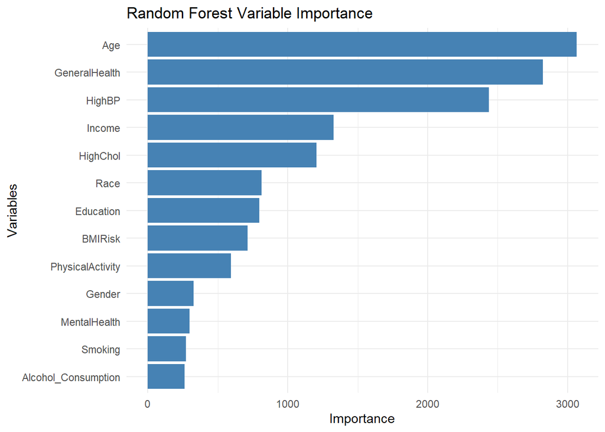

```r
# Variable importance
importance_df <- data.frame(
  Variable = names(rf_ranger$variable.importance),
  Importance = rf_ranger$variable.importance
) %>%
  arrange(desc(Importance))

# Variable importance plot
ggplot(importance_df, aes(x = reorder(Variable, Importance), y = Importance)) +
  geom_col(fill = "steelblue") +
  coord_flip() +
  labs(x = "Variables", y = "Importance", title = "Random Forest Variable Importance") +
  theme_minimal()
```

## 8.4 Comparison of models

```r
compare_results <- data.frame(
  Model = c("Logistic Regression", "Random Forest", "Null Model"),
  Accuracy = c(logit_cm$overall["Accuracy"],
               rf_cm$overall["Accuracy"],
               null_cm$overall["Accuracy"]),
  Sensitivity = c(logit_cm$byClass["Sensitivity"],
                  rf_cm$byClass["Sensitivity"],
                  null_cm$byClass["Sensitivity"]),
  Specificity = c(logit_cm$byClass["Specificity"],
                  rf_cm$byClass["Specificity"],
                  null_cm$byClass["Specificity"])
)

kable(compare_results, digits = 3) %>% kable_styling()
```

| Model | Accuracy | Sensitivity | Specificity |
| --- | --- | --- | --- |
| Logistic Regression | 0.842 | 0.974 | 0.158 |
| Random Forest | 0.844 | 0.979 | 0.139 |
| Null Model | 0.838 | 1.000 | 0.000 |

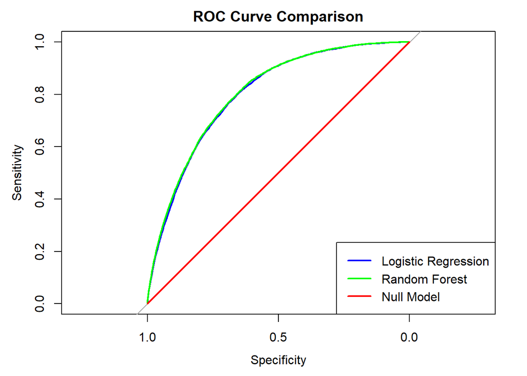

```r
# ROC curve analysis for two models


# Logistic model
logit_probs <- predict(logit_model, newdata = test_data, type = "response")
logit_roc <- roc(test_data$Diabetes, logit_probs, levels = c("No", "Yes"))
# Random Forest model
rf_probs <- predict(rf_ranger, data = test_data)$predictions[, "Yes"]
rf_roc <- roc(test_data$Diabetes, rf_probs, levels = c("No", "Yes"))
# Plot all ROC curves together
plot(logit_roc, col = "blue", lwd = 2, main = "ROC Curve Comparison")
plot(rf_roc, col = "green", lwd = 2, add = TRUE)
plot(null_roc, col = "red", lwd = 2, add = TRUE)
legend("bottomright", legend = c("Logistic Regression", "Random Forest", "Null Model"),
       col = c("blue", "green", "red"), lwd = 2)
```

```r
# Calculate AUC values
auc_logit <- auc(logit_roc)
auc_rf    <- auc(rf_roc)
auc_null  <- auc(null_roc)

# Calculate Accuracy values
acc_logit <- logit_cm$overall["Accuracy"]
acc_rf    <- rf_cm$overall["Accuracy"]
acc_null  <- null_cm$overall["Accuracy"]

# Create comparison table
compare_metrics <- data.frame(
  Model = c("Logistic Regression", "Random Forest", "Null Model"),
  AUC = c(auc_logit, auc_rf, auc_null),
  Accuracy = c(acc_logit, acc_rf, null_cm$overall["Accuracy"])
)

kable(compare_metrics, digits = 3) %>% kable_styling()
```

| Model | AUC | Accuracy |
| --- | --- | --- |
| Logistic Regression | 0.800 | 0.842 |
| Random Forest | 0.803 | 0.844 |
| Null Model | 0.500 | 0.838 |

```r
# Extract coefficients and calculate Odds Ratios
glm_coefs <- summary(logit_model)$coefficients

# Odds Ratios و 95% CI
odds_ratios <- exp(coef(logit_model))
confint_glm <- exp(confint(logit_model))
# Logistic Regression summary
glm_coefs <- summary(logit_model)$coefficients

# Odds Ratio
odds_ratios <- exp(coef(logit_model))

# Confidence Interval
confint_glm <- exp(confint.default(logit_model))

# Table summarizing all aspects
glm_results <- data.frame(
  Variable = rownames(glm_coefs),
  Beta = round(glm_coefs[, "Estimate"], 3),
  OR = round(odds_ratios, 3),
  CI_lower = round(confint_glm[, 1], 3),
  CI_upper = round(confint_glm[, 2], 3),
  p_value = round(glm_coefs[, "Pr(>|z|)"], 3)
)

kable(glm_results, digits = 3, caption = "Logistic Regression Odds Ratios and Interpretation", row.names = FALSE) %>%
  kable_styling()
```

Logistic Regression Odds Ratios and Interpretation

| Variable | Beta | OR | CI_lower | CI_upper | p_value |
| --- | --- | --- | --- | --- | --- |
| (Intercept) | -5.069 | 0.006 | 0.004 | 0.010 | 0.000 |
| GenderFemale | -0.189 | 0.828 | 0.805 | 0.851 | 0.000 |
| Age | 0.025 | 1.025 | 1.024 | 1.026 | 0.000 |
| RaceBlack | 0.459 | 1.583 | 1.511 | 1.657 | 0.000 |
| RaceAsian | 0.454 | 1.575 | 1.429 | 1.736 | 0.000 |
| RaceNative American | 0.581 | 1.787 | 1.626 | 1.965 | 0.000 |
| RaceHispanic | 0.298 | 1.348 | 1.280 | 1.419 | 0.000 |
| RaceOther | 0.277 | 1.320 | 1.228 | 1.418 | 0.000 |
| Income$10k-<$15k | 0.064 | 1.066 | 0.965 | 1.178 | 0.205 |
| Income$15k-<$20k | -0.005 | 0.995 | 0.904 | 1.095 | 0.922 |
| Income$20k-<$25k | -0.083 | 0.920 | 0.840 | 1.008 | 0.073 |
| Income$25k-<$35k | -0.092 | 0.912 | 0.838 | 0.993 | 0.033 |
| Income$35k-<$50k | -0.144 | 0.866 | 0.795 | 0.942 | 0.001 |
| Income$50k-<$75k | -0.206 | 0.814 | 0.748 | 0.886 | 0.000 |
| Income$75k-<$100k | -0.256 | 0.774 | 0.710 | 0.845 | 0.000 |
| Income$100k-<$150k | -0.266 | 0.767 | 0.702 | 0.837 | 0.000 |
| Income$150k-<$200k | -0.380 | 0.684 | 0.619 | 0.756 | 0.000 |
| EducationElementary | -0.287 | 0.750 | 0.501 | 1.125 | 0.165 |
| EducationSome HS | -0.333 | 0.717 | 0.481 | 1.069 | 0.102 |
| EducationHS graduate | -0.375 | 0.687 | 0.463 | 1.021 | 0.063 |
| EducationSome college | -0.321 | 0.725 | 0.488 | 1.077 | 0.111 |
| EducationCollege graduate | -0.476 | 0.621 | 0.418 | 0.923 | 0.018 |
| GeneralHealthVery good | 0.552 | 1.737 | 1.618 | 1.866 | 0.000 |
| GeneralHealthGood | 1.223 | 3.399 | 3.172 | 3.642 | 0.000 |
| GeneralHealthFair | 1.722 | 5.595 | 5.203 | 6.017 | 0.000 |
| GeneralHealthPoor | 1.977 | 7.222 | 6.648 | 7.845 | 0.000 |
| MentalHealthPoor mental health | -0.084 | 0.919 | 0.892 | 0.947 | 0.000 |
| BMIRiskNormal | 0.791 | 2.206 | 2.127 | 2.289 | 0.000 |
| HighBPHigh | 0.820 | 2.270 | 2.202 | 2.340 | 0.000 |
| HighCholHigh | 0.608 | 1.836 | 1.785 | 1.888 | 0.000 |
| PhysicalActivityInactive | 0.264 | 1.303 | 1.264 | 1.342 | 0.000 |
| SmokingSmoker | -0.158 | 0.854 | 0.818 | 0.892 | 0.000 |
| Alcohol_ConsumptionYes | -0.823 | 0.439 | 0.407 | 0.474 | 0.000 |

# 9 Conclusion